# Computer Vision Project

## PART B

```python
from google.colab import drive #mounting drive
drive.mount('/content/drive')
```

University X is currently undergoing some research involving understanding the characteristics of flowers. They already have have invested on curating sample images. They require an automation which can create a classifier capable of determining a flower’s species from a photo

**Import and read oxflower17 dataset from tflearn and split into X and Y while loading.**

```python
pip install tflearn
```

```
     |████████████████████████████████| 107 kB 31.5 MB/s
```

```python
import tflearn.datasets.oxflower17 as oxflower17
```

```
WARNING:tensorflow:From /usr/local/lib/python3.7/dist-packages/tensorflow/python/compat/v2_compat.py:107: disable_resource_variables (from tensorflow.python.ops.variable_scope) is deprecated and will be removed in a future version.
Instructions for updating:
non-resource variables are not supported in the long term
```

```python
x,y = oxflower17.load_data()
```

```
Downloading Oxford 17 category Flower Dataset, Please wait...
```

```
100.0% 60276736 / 60270631
```

```
Succesfully downloaded 17flowers.tgz 60270631 bytes.
File Extracted
Starting to parse images...
Parsing Done!
```

```python
x[0]
```

[output not shown]

```python
y[0]
```

```
0
```

**Print Number of images and shape of the images.**

```python
x.shape
```

```
(1360, 224, 224, 3)
```

datset has 1360 images.

shape of images is 224 width 224 height off each image and has 3 channels.

**Print count of each class from y**

```python
from collections import Counter
print(Counter(y))
```

```
Counter({0: 80, 3: 80, 2: 80, 7: 80, 13: 80, 4: 80, 12: 80, 10: 80, 15: 80, 5: 80, 8: 80, 16: 80, 11: 80, 1: 80, 9: 80, 6: 80, 14: 80})
```

**Display 5 random images.**

```
[ 10 274 288 930 473]
```

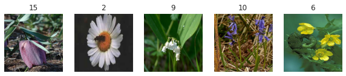

```python
rand = np.random.randint(0, len(x), 5)
print(rand)
rows = 1
columns = 5
j=0
plt.figure(figsize=(10,10))
for i in rand :
    plt.subplot(rows, columns, j+1)
    plt.imshow(x[i])
    plt.title(y[i])
    plt.axis('off')
    j=j+1
plt.show()
```

**Select any image from the dataset and assign it to a variable.**

```
(([], <a list of 0 Text major ticklabel objects>),
 ([], <a list of 0 Text major ticklabel objects>))
```

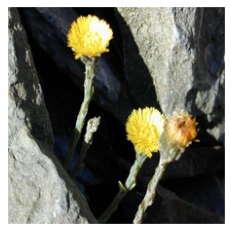

```python
img= x[200]
plt.imshow(img)
plt.xticks([]), plt.yticks([])
```

**Transform the image into grayscale format and display the same.**

```python
img_gray=cv2.cvtColor(img, cv2.COLOR_BGR2GRAY)
```

```
(([], <a list of 0 Text major ticklabel objects>),
 ([], <a list of 0 Text major ticklabel objects>))
```

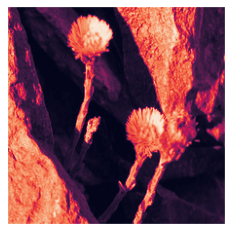

```python
plt.imshow(img_gray)
plt.xticks([]), plt.yticks([])
```

**Apply a filter to sharpen the image and display the image before and after sharpening.**

```python
kernel = np.array([[-1,-1,-1], [-1,9,-1], [-1,-1,-1]])
img_sharp = cv2.filter2D(img, -1, kernel)
```

```
WARNING:matplotlib.image:Clipping input data to the valid range for imshow with RGB data ([0..1] for floats or [0..255] for integers).
```

```
(-0.5, 223.5, 223.5, -0.5)
```

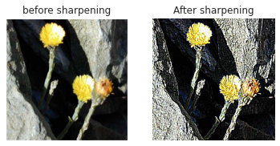

```python
plt.subplot(1, 2, 1)
plt.imshow(img)
plt.title("before sharpening")
plt.xticks([]), plt.yticks([])
plt.subplot(1, 2, 2)
plt.imshow(img_sharp)
plt.title("After sharpening")
plt.axis('off')
```

**Apply a filter to blur the image and display the image before and after blur**

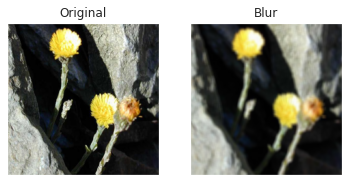

```python
Filter_Blur = cv2.blur(img,(5,5))
plt.subplot(121),plt.imshow(img),plt.title('Original')
plt.xticks([]), plt.yticks([])
plt.subplot(122),plt.imshow(Filter_Blur),plt.title('Blur')
plt.xticks([]), plt.yticks([])
plt.show()
```

**Display all the 4 images from above questions besides each other to observe the difference**

```
WARNING:matplotlib.image:Clipping input data to the valid range for imshow with RGB data ([0..1] for floats or [0..255] for integers).
```

```
(-0.5, 223.5, 223.5, -0.5)
```

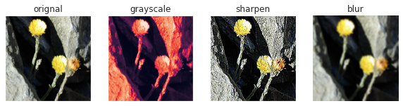

```python
plt.figure(figsize=(10,10))
plt.subplot(1, 4, 1)
plt.imshow(img)
plt.title("orignal")
plt.xticks([]), plt.yticks([])
plt.subplot(1, 4, 2)
plt.imshow(img_gray)
plt.title("grayscale")
plt.xticks([]), plt.yticks([])
plt.subplot(1, 4, 3)
plt.imshow(img_sharp)
plt.title("sharpen")
plt.xticks([]), plt.yticks([])
plt.subplot(1, 4, 4)
plt.imshow(Filter_Blur)
plt.title("blur")
plt.xticks([]), plt.yticks([])
plt.axis('off')
```

Sharpen image provides more details from the image.

Orignal image is compressed and looks blured.

Grayscale image is better for model training.

**Split the data into train and test with 80:20 proportion.**

```python
x = x/ 255 #normalise the images
```

```python
X_train, X_test, y_train, y_test = train_test_split(x, y, test_size=0.20, random_state=1)
```

```python
print(X_train.shape)
print(y_train.shape)
print(X_test.shape)
print(y_test.shape)
```

```
(1088, 224, 224, 3)
(1088,)
(272, 224, 224, 3)
(272,)
```

*Data augmentation*

```python
datagen = ImageDataGenerator(
        featurewise_center=False,  # set input mean to 0 over the dataset
        samplewise_center=False,  # set each sample mean to 0
        featurewise_std_normalization=False,  # divide inputs by std of the dataset
        samplewise_std_normalization=False,  # divide each input by its std
        zca_whitening=False,  # apply ZCA whitening
        rotation_range = 30,  # randomly rotate images in the range (degrees, 0 to 180)
        zoom_range = 0.2, # Randomly zoom image
        width_shift_range=0.1,  # randomly shift images horizontally (fraction of total width)
        height_shift_range=0.1,  # randomly shift images vertically (fraction of total height)
        horizontal_flip = True,  # randomly flip images
        vertical_flip=False)  # randomly flip images


datagen.fit(X_train)
val_gen = ImageDataGenerator(
        featurewise_center=False,  # set input mean to 0 over the dataset
        samplewise_center=False,  # set each sample mean to 0
        featurewise_std_normalization=False,  # divide inputs by std of the dataset
        samplewise_std_normalization=False,  # divide each input by its std
        zca_whitening=False,  # apply ZCA whitening
        rotation_range = 30,  # randomly rotate images in the range (degrees, 0 to 180)
        zoom_range = 0.2, # Randomly zoom image
        width_shift_range=0.1,  # randomly shift images horizontally (fraction of total width)
        height_shift_range=0.1,  # randomly shift images vertically (fraction of total height)
        horizontal_flip = True,  # randomly flip images
        vertical_flip=False)

val_gen.fit(X_test)
```

```python
print(X_train.shape)
print(y_train.shape)
print(X_test.shape)
print(y_test.shape)
```

```
(1088, 224, 224, 3)
(1088,)
(272, 224, 224, 3)
(272,)
```

**Train a model using any Supervised Learning algorithm and share performance metrics on test data.**

```python
nsamples, nx, ny, nrgb = X_train.shape #converting 4d array to a 2d array for model.fit()
X_train2 = X_train.reshape((nsamples,nx*ny*nrgb))
X_train2.shape
```

```
(1088, 150528)
```

```python
nsamples, nx, ny, nrgb =X_test.shape #converting 4d array to a 2d array for model.predict()
X_test2 = X_test.reshape((nsamples,nx*ny*nrgb))
X_test2.shape
```

```
(272, 150528)
```

```python
from sklearn.ensemble import RandomForestClassifier
model=RandomForestClassifier()
model.fit(X_train2,y_train)
y_pred=model.predict(X_test2)
print(accuracy_score(y_pred,y_test))
print(classification_report(y_pred,y_test))
```

```
0.5
              precision    recall  f1-score   support

           0       0.30      0.23      0.26        13
           1       0.40      0.32      0.35        19
           2       0.74      1.00      0.85        14
           3       0.28      0.56      0.37         9
           4       0.64      0.50      0.56        18
           5       0.22      0.29      0.25        14
           6       0.64      0.45      0.53        20
           7       0.56      0.53      0.54        19
           8       0.54      0.58      0.56        12
           9       0.48      0.45      0.47        22
          10       0.53      0.50      0.51        18
          11       0.36      0.29      0.32        17
          12       0.50      0.73      0.59        11
          13       0.47      0.62      0.53        13
          14       0.28      0.50      0.36        10
          15       0.55      0.35      0.43        17
          16       0.95      0.69      0.80        26

    accuracy                           0.50       272
   macro avg       0.50      0.50      0.49       272
weighted avg       0.53      0.50      0.50       272
```

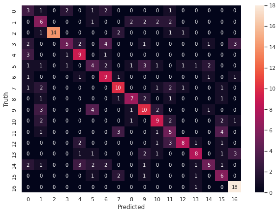

```python
from sklearn.metrics import confusion_matrix
import seaborn as sns

cm=confusion_matrix(y_test,y_pred)

plt.figure(figsize=(10,7))
sns.heatmap(cm,annot=True,fmt='d')
plt.xlabel('Predicted')
plt.ylabel('Truth')
plt.show()
```

**Train a model using Neural Network and share performance metrics on test data.**

```python
model1 = tf.keras.models.Sequential([
    tf.keras.layers.Flatten(),
    tf.keras.layers.Dense(1024, activation='relu'),
    tf.keras.layers.Dense(512, activation='relu'),
    tf.keras.layers.Dense(128, activation='relu'),
    tf.keras.layers.Dense(64, activation='relu'),
    tf.keras.layers.Dense(17, activation='softmax')
])
```

```python
model1.compile(loss="sparse_categorical_crossentropy", metrics=["accuracy"], optimizer="adam")
```

```python
history1=model1.fit(datagen.flow(X_train, y_train, batch_size=64),validation_data=(X_test,y_test),epochs=30,verbose=1)
```

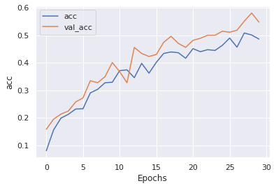

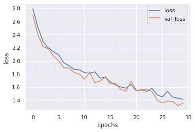

```python
def plot_graphs(history, string):
  plt.plot(history.history[string])
  plt.plot(history.history['val_'+string])
  plt.xlabel("Epochs")
  plt.ylabel(string)
  plt.legend([string, 'val_'+string])
  plt.show()


plot_graphs(history1, 'acc')
print(" ")
plot_graphs(history1, 'loss')
```

```python
results2 = model1.evaluate(X_test, y_test)
print('Test accuracy: ', results2[1])
print('Test loss: ', results2[0])
```

```
Test accuracy:  0.5477941
Test loss:  1.313175180379082
```

```python
Y_pred = model1.predict(X_test, batch_size=200, verbose=0)
```

```python
# As our outputs are probabilities so we will try to get the output class from these probablities by getting the maximum value
y_pred_final=[]
for i in Y_pred:
  y_pred_final.append(np.argmax(i))
```

```python
print(classification_report(y_test,y_pred_final))
```

```
              precision    recall  f1-score   support

           0       0.17      0.70      0.28        10
           1       0.46      0.40      0.43        15
           2       0.78      0.37      0.50        19
           3       0.00      0.00      0.00        18
           4       0.57      0.29      0.38        14
           5       0.59      0.72      0.65        18
           6       0.42      0.57      0.48        14
           7       0.42      0.72      0.53        18
           8       0.53      0.69      0.60        13
           9       0.79      0.71      0.75        21
          10       1.00      0.71      0.83        17
          11       0.60      0.21      0.32        14
          12       0.60      0.75      0.67        16
          13       0.79      0.65      0.71        17
          14       0.36      0.22      0.28        18
          15       0.78      0.64      0.70        11
          16       0.75      0.95      0.84        19

    accuracy                           0.55       272
   macro avg       0.57      0.55      0.53       272
weighted avg       0.58      0.55      0.53       272
```

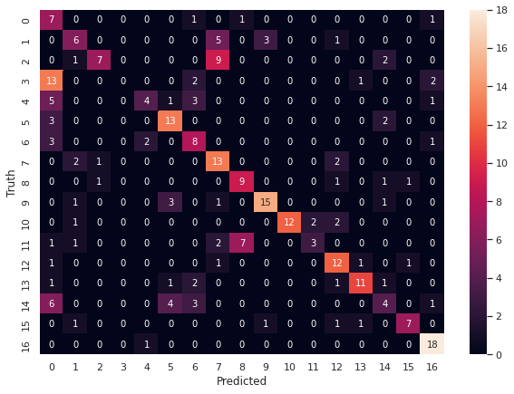

```python
cm=confusion_matrix(y_test,y_pred_final)

plt.figure(figsize=(10,7))
sns.heatmap(cm,annot=True,fmt='d')
plt.xlabel('Predicted')
plt.ylabel('Truth')
plt.show()
```

**Train a model using a basic CNN and share performance metrics on test data.**

```python
model2 = tf.keras.models.Sequential([
    # This is the first convolution
    tf.keras.layers.Conv2D(64, (3,3), activation='relu', input_shape=(224, 224, 3)),
    tf.keras.layers.MaxPooling2D(2, 2),
    tf.keras.layers.BatchNormalization(),
    # The second convolution
    tf.keras.layers.Conv2D(64, (3,3), activation='relu'),
    tf.keras.layers.MaxPooling2D(2,2),
    tf.keras.layers.Conv2D(128, (3,3), activation='relu'),
    tf.keras.layers.MaxPooling2D(2,2),
    tf.keras.layers.Conv2D(128, (3,3), activation='relu'),
    tf.keras.layers.MaxPooling2D(2,2),
    # Flatten the results to feed into a DNN
    tf.keras.layers.Flatten(),
    tf.keras.layers.BatchNormalization(),
    tf.keras.layers.Dropout(0.5),
    tf.keras.layers.Dense(512, activation='relu'),
    tf.keras.layers.Dense(128, activation='relu'),
    # 512 neuron hidden layer
    tf.keras.layers.Dense(128, activation='relu'),
    tf.keras.layers.BatchNormalization(),
    tf.keras.layers.Dense(17, activation='softmax')
])
```

```
WARNING:tensorflow:From /usr/local/lib/python3.7/dist-packages/keras/layers/normalization/batch_normalization.py:532: _colocate_with (from tensorflow.python.framework.ops) is deprecated and will be removed in a future version.
Instructions for updating:
Colocations handled automatically by placer.
```

```python
model2.compile(loss="sparse_categorical_crossentropy", metrics=["accuracy"], optimizer="adam")
```

```python
model2.summary()
```

```
Model: "sequential_1"
_________________________________________________________________
 Layer (type)                Output Shape              Param #
=================================================================
 conv2d (Conv2D)             (None, 222, 222, 64)      1792

 max_pooling2d (MaxPooling2D  (None, 111, 111, 64)     0
 )

 batch_normalization (BatchN  (None, 111, 111, 64)     256
 ormalization)

 conv2d_1 (Conv2D)           (None, 109, 109, 64)      36928

 max_pooling2d_1 (MaxPooling  (None, 54, 54, 64)       0
 2D)

 conv2d_2 (Conv2D)           (None, 52, 52, 128)       73856

 max_pooling2d_2 (MaxPooling  (None, 26, 26, 128)      0
 2D)

 conv2d_3 (Conv2D)           (None, 24, 24, 128)       147584

 max_pooling2d_3 (MaxPooling  (None, 12, 12, 128)      0
 2D)

 flatten_1 (Flatten)         (None, 18432)             0

 batch_normalization_1 (Batc  (None, 18432)            73728
 hNormalization)

 dropout (Dropout)           (None, 18432)             0

 dense_5 (Dense)             (None, 512)               9437696

 dense_6 (Dense)             (None, 128)               65664

 dense_7 (Dense)             (None, 128)               16512

 batch_normalization_2 (Batc  (None, 128)              512
 hNormalization)

 dense_8 (Dense)             (None, 17)                2193

=================================================================
Total params: 9,856,721
Trainable params: 9,819,473
Non-trainable params: 37,248
_________________________________________________________________
```

```python
history2=model2.fit(datagen.flow(X_train, y_train, batch_size=64),validation_data=(X_test,y_test),epochs=50,verbose=1)
```

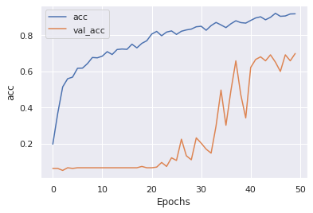

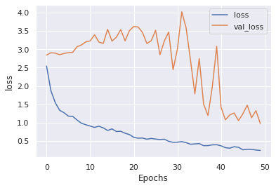

```python
plot_graphs(history2, 'acc')
print(" ")
plot_graphs(history2, 'loss')
```

```python
model2.save("drive/My Drive/Colab Notebooks/com vis/CNNf")
```

```python
results2 = model2.evaluate(X_test, y_test)
print('Test accuracy: ', results2[1])
print('Test loss: ', results2[0])
```

```
Test accuracy:  0.6985294
Test loss:  1.0219893946367151
```

```python
Y_pred = model2.predict(X_test, batch_size=200, verbose=0)
```

```python
y_pred_final=[]
for i in Y_pred:
  y_pred_final.append(np.argmax(i))
```

```python
from sklearn.metrics import classification_report
print(classification_report(y_test,y_pred_final))
```

```
              precision    recall  f1-score   support

           0       0.44      0.40      0.42        10
           1       0.71      0.67      0.69        15
           2       1.00      0.63      0.77        19
           3       0.75      0.83      0.79        18
           4       0.60      0.86      0.71        14
           5       0.64      0.50      0.56        18
           6       0.75      0.86      0.80        14
           7       0.63      0.67      0.65        18
           8       0.83      0.77      0.80        13
           9       0.78      0.86      0.82        21
          10       0.93      0.82      0.87        17
          11       0.53      0.71      0.61        14
          12       0.91      0.62      0.74        16
          13       0.71      0.71      0.71        17
          14       0.36      0.28      0.31        18
          15       0.43      0.82      0.56        11
          16       1.00      0.84      0.91        19

    accuracy                           0.70       272
   macro avg       0.71      0.70      0.69       272
weighted avg       0.72      0.70      0.70       272
```

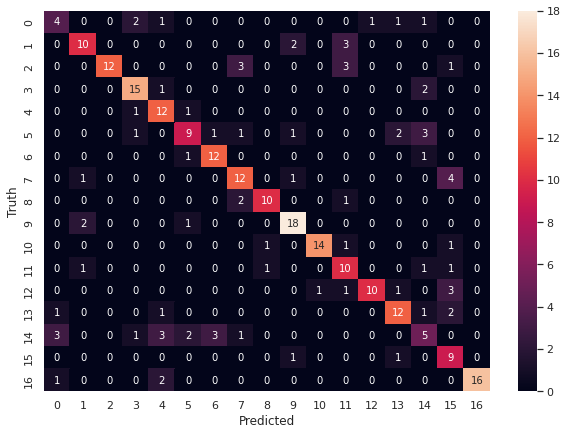

```python
cm=confusion_matrix(y_test,y_pred_final)

plt.figure(figsize=(10,7))
sns.heatmap(cm,annot=True,fmt='d')
plt.xlabel('Predicted')
plt.ylabel('Truth')
plt.show()
```

**Predict the class/label of image ‘Prediction.jpg’ using best performing model and share predicted label.**

Best model is CNN we will use CNN for prediction.

```python
test_image = cv2.imread("drive/My Drive/Colab Notebooks/com vis/Prediction.jpg",cv2.IMREAD_GRAYSCALE)
print(test_image)
```

```
[[ 5  4  0 ...  0  0  0]
 [ 7 14  5 ...  0  0  0]
 [ 7 20 19 ...  0  0  0]
 ...
 [10 10 11 ...  0  0  0]
 [10  7  7 ...  0  0  0]
 [ 6  4  4 ...  0  0  0]]
```

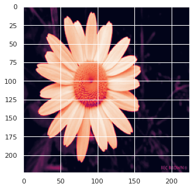

```python
plt.figure(figsize = (5,5))
plt.imshow(test_image)
```

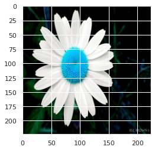

```python
test_image = cv2.imread("drive/My Drive/Colab Notebooks/com vis/Prediction.jpg",cv2.IMREAD_COLOR)
test_image = cv2.resize(test_image, (224, 224),
               interpolation = cv2.INTER_NEAREST)
plt.imshow(test_image)
```

```python
test_image = np.expand_dims(test_image, axis=0)
```

```python
clas1= model2.predict(test_image)
```

```python
clas1
```

```
array([[0., 0., 0., 0., 0., 0., 0., 0., 0., 0., 0., 0., 0., 1., 0., 0.,
        0.]], dtype=float32)
```

```python
np.argmax(clas1)
```

```
13
```

model is predicting given flower as label 13.